# G64190069_Rizal Mujahiddan_UAS_AED22.pdf

Rizal Mujahiddan

6/10/2022

# Buka Data terlebih Dahulu

```r
data_uas <- read.csv("DATA UAS AED - 2022 - DATA SET.csv")
head(data_uas)
```

```
##   x  y
## 1 1  0
## 2 1 11
## 3 1 12
## 4 1  3
## 5 2 60
## 6 2 73
```

# Summary

```r
summary(data_uas)
```

```
##        x              y
##  Min.   : 1.0   Min.   :    0.0
##  1st Qu.: 3.0   1st Qu.:  187.8
##  Median : 5.5   Median : 1193.5
##  Mean   : 5.5   Mean   : 2189.8
##  3rd Qu.: 8.0   3rd Qu.: 3585.0
##  Max.   :10.0   Max.   :10000.0
```

# Check Outlier

## X

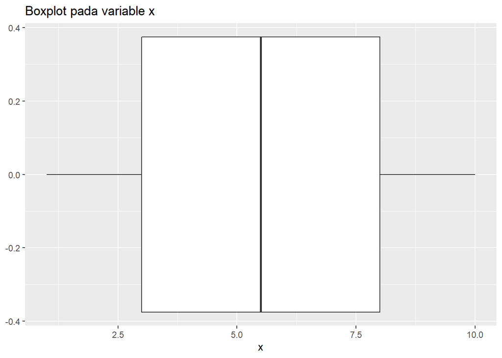

```r
ggplot(data_uas,aes(x=x)) + geom_boxplot() +
  ggtitle("Boxplot pada variable x")
```

- Tidak ada outlier yang perlu dikhawatirkan
- Cenderung mendekati normal dikarenakan garis mediannya membagi panjang boxplot itu sendiri

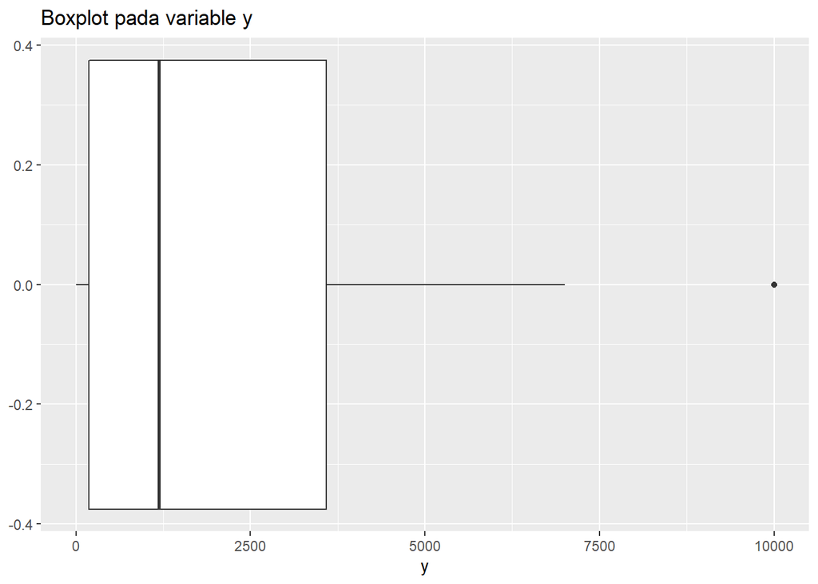

```r
ggplot(data_uas,aes(x=y)) + geom_boxplot() +
  ggtitle("Boxplot pada variable y")
```

- Ada outlier
- Cenderung tidak normal (Panjang sebelah)

# Density Plot

## x

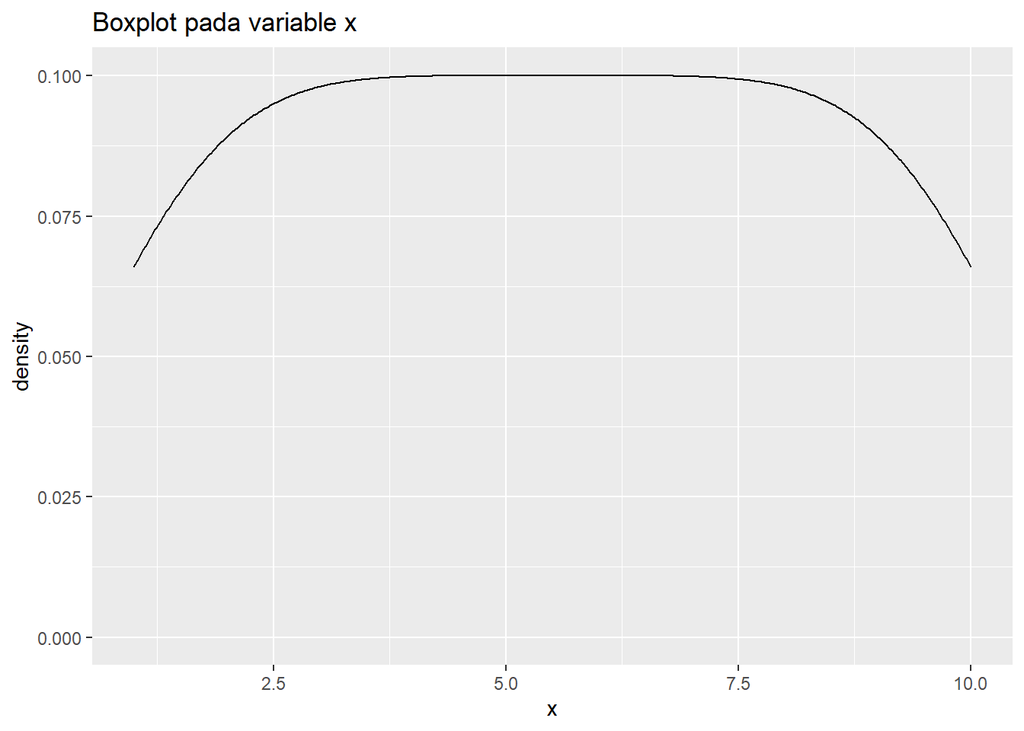

```r
ggplot(data_uas,aes(x=x)) + geom_density() +
  ggtitle("Boxplot pada variable x")
```

- Bisa Dikatakan mendekati normal saja, dikarenakan masih ada kemungkinan distribusi x itu mendekati distribusi **uniform**
- kemudian ternyata kurang begitu memuncak distribusinya

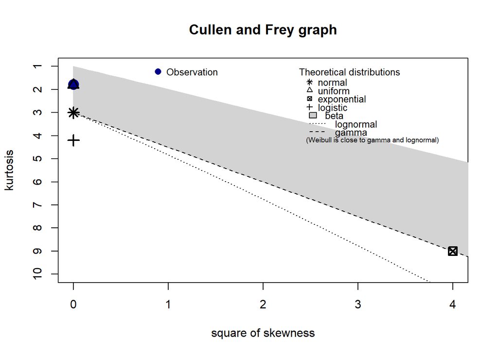

```
## summary statistics
## ------
## min:  1   max:  10
## median:  5.5
## mean:  5.5
## estimated sd:  2.908872
## estimated skewness:  0
## estimated kurtosis:  1.774137
```

```r
descdist(data_uas$x)
```

- Sudah dipastikan dengan **Cullen and frey graph** , bahwa data x merupakan data berdistribusi uniform bukan normal

## y

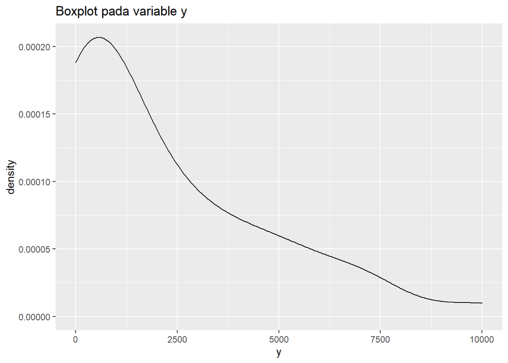

```r
ggplot(data_uas,aes(x=y)) + geom_density() +
  ggtitle("Boxplot pada variable y")
```

- distribusinya menjulur kekanan
- distribusi masih membingungkan dikarenakan grafiknya tidak mewakili grafik apapun ya

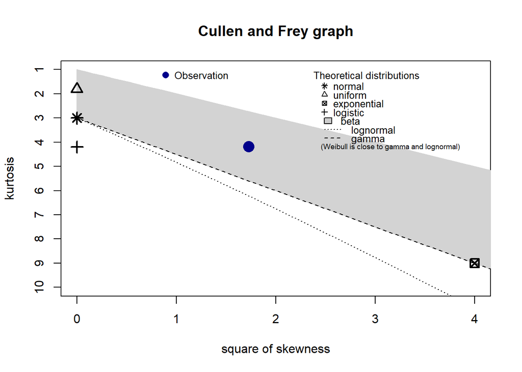

```
## summary statistics
## ------
## min:  0   max:  10000
## median:  1193.5
## mean:  2189.8
## estimated sd:  2515.642
## estimated skewness:  1.314584
## estimated kurtosis:  4.174921
```

```r
descdist(data_uas$y)
```

- Membingungkan, dikarenakan data tersebut masuk ke distribusi beta, bukan ke distribusi yang lainnya. maka diperlukan **transformasi data**

# Scatterplot

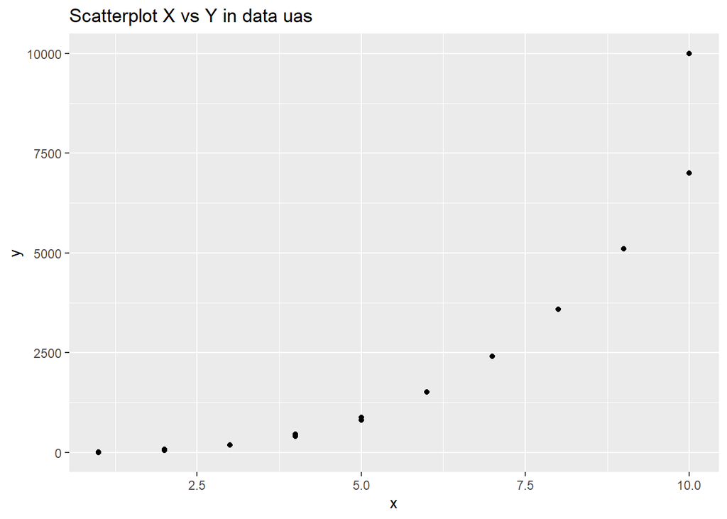

```r
ggplot(data_uas,aes(x,y)) + geom_point() +
  ggtitle("Scatterplot X vs Y in data uas")
```

- JIka Diperhatikan, hubungan antara x dan y bukanlah linear
- kemungkinan hubungan data tersebut merupakan eksponensial maupun polinomial dikarenakan adanya cekung keatas.

# Transformasi data

Berdasarkan dari internet dan artikel, dengan menggunakan bestNormalize. maka akan ditunjukkan dengan metode terbaik untuk menormalisasikan data tersebut

```r
set.seed(1234)
ytransform <- bestNormalize(data_uas$y,standardize = FALSE)
ytransform
```

```
## Best Normalizing transformation with 40 Observations
##  Estimated Normality Statistics (Pearson P / df, lower => more normal):
##  - arcsinh(x): 1.72
##  - Log_b(x+a): 1.88
##  - No transform: 2.56
##  - orderNorm (ORQ): 1.56
##  - sqrt(x + a): 1.4
##  - Yeo-Johnson: 1.4
## Estimation method: Out-of-sample via CV with 10 folds and 5 repeats
##
## Based off these, bestNormalize chose:
## Non-Standardized sqrt(x + a) Transformation with 40 nonmissing obs.:
##  Relevant statistics:
##  - a = 0
##  - mean (before standardization) = 38.06826
##  - sd (before standardization) = 27.5608
```

- Normalisasi yang bagus adalah dengan mengakarkan nilai y tersebut, sesuai dengan fungsi tersebut

```r
data_uas$y.t <- ytransform$x.t
ytransform$x.t
```

```
##  [1]   0.000000   3.316625   3.464102   1.732051   7.745967   8.544004
##  [7]   7.681146   7.211103  13.711309  13.674794  13.784049  13.527749
## [13]  21.142375  21.236761  21.142375  20.024984  29.461840  29.614186
## [19]  29.614186  28.301943  38.923001  38.858718  38.884444  38.910153
## [25]  49.000000  48.989795  48.989795  49.000000  59.908263  59.874870
## [31]  59.874870  59.874870  71.456280  71.407283  71.421285  71.421285
## [37]  83.642095  83.689904  83.671979 100.000000
```

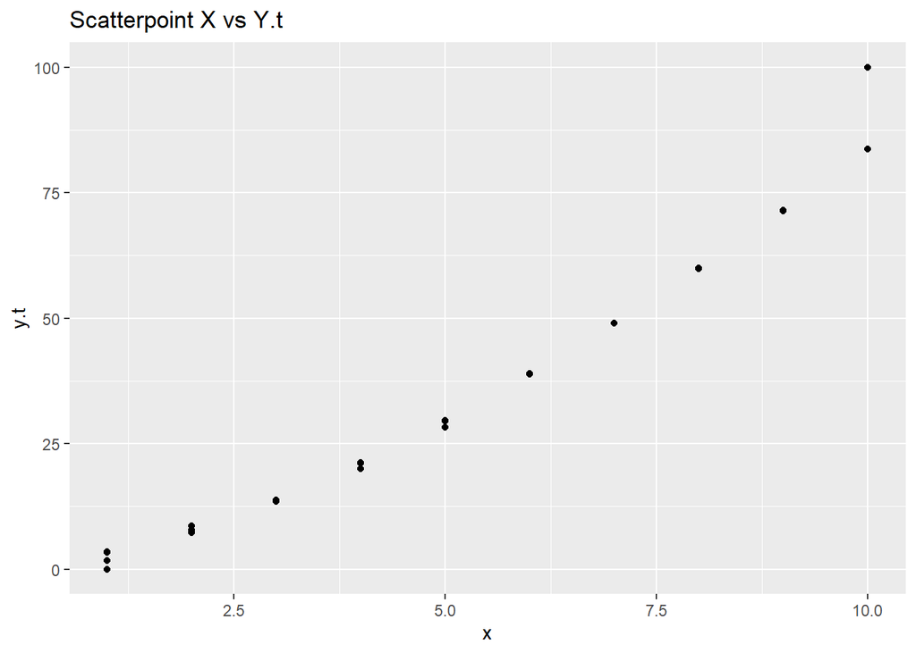

```r
ggplot(data_uas,aes(x,y.t)) + geom_point() + ggtitle("Scatterpoint X vs Y.t")
```

* Jika diperhatikan, nilainya lumayan bagus, tetapi permasalahnnya mengapa ada nilai yang menumpuk pada x yang sama, inilah permasalahannya

# Duga Parameter

## linear regression

```r
linear_reg <- lm('y.t ~ x',data=data_uas)
summary(linear_reg)
```

```
##
## Call:
## lm(formula = "y.t ~ x", data = data_uas)
##
## Residuals:
##    Min     1Q Median     3Q    Max
## -5.096 -3.088 -1.350  2.318 19.904
##
## Coefficients:
##             Estimate Std. Error t value Pr(>|t|)
## (Intercept) -13.2996     1.6049  -8.287 4.81e-10 ***
## x             9.3396     0.2586  36.109  < 2e-16 ***
## ---
## Signif. codes:  0 '***' 0.001 '**' 0.01 '*' 0.05 '.' 0.1 ' ' 1
##
## Residual standard error: 4.699 on 38 degrees of freedom
## Multiple R-squared:  0.9717, Adjusted R-squared:  0.9709
## F-statistic:  1304 on 1 and 38 DF,  p-value: < 2.2e-16
```

nilai duga dari suatu linear regresi adalah y = 9.3396 * - 13.2996